# Turbidity Post-Cal Exploration

Author

Perry

Published

April 8, 2025

# Read in Data

```r
library(tidyverse)
library(lme4)
library(lmerTest)
library(lattice)
library(emmeans)
```

```r
df_turb <- read_csv(here::here('05_SpecialStudies/QA_TurbiditySensors/turbiditysensors.csv'))
df_turb <- df_turb %>%
  mutate(PostCalCentered = df_turb$PostCalVal - 124, # center the data at 0
         PostCalDate = as.Date(PostCalDate, format = '%m/%d/%Y'))
```

# Assumptions

- sources of error accumulated between calibration and post-calibration are the same for all data points
  - ie. no significant differences in drift between sondes or sites
- sources of error accumulated between calibration and post-calibration are negligible
  - ie. the expected value at post-cal remains 124 (the standard)
- the person doing the calibrations did not significantly affect the values
- all sondes were calibrated in the old standard and post-calibrated in the new standard
  - **checking this one**
- the post-cal standard was 124 for all sondes

# Plots

## Original

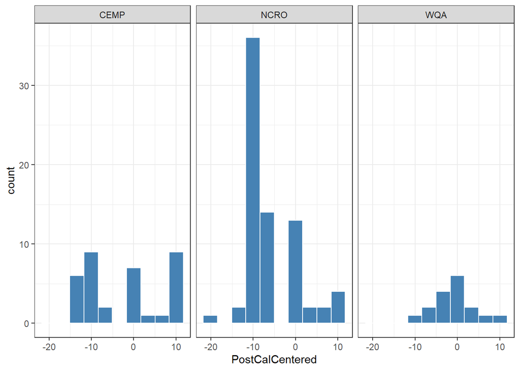

```r
ggplot(df_turb, aes(x = PostCalCentered)) +
  geom_histogram(bins = 10, fill = 'steelblue', color = 'white') +
  facet_wrap(~ Program) +
  theme_bw()
```

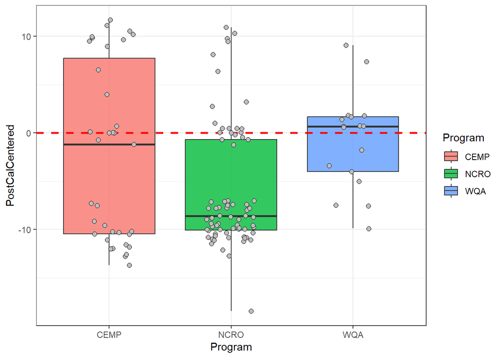

```r
ggplot(df_turb, aes(x = Program, y = PostCalCentered, fill = Program)) +
  geom_boxplot(alpha = 0.8) +
  geom_hline(yintercept = 0, color = 'red', linetype = 'dashed', linewidth = 1) +
  geom_jitter(width = 0.2, shape = 21, size = 2, fill = 'gray') +
  theme_bw()
```

**Conclusions:**

WQA looks good. NCRO and CEMP both seem to be bimodal, with two populations: an upper one (that includes 0) and a lower one. Therefore, we will split those populations to investigate metadata.

## Population Split

```r
df_split <- df_turb %>%
  mutate(
    ProgramSplit = case_when(
      Program == 'NCRO' & PostCalCentered < -5 ~ 'NCRO_low',
      Program == 'NCRO' & PostCalCentered >= -5 ~ 'NCRO_high',
      Program == 'CEMP' & PostCalCentered < -5 ~ 'CEMP_low',
      Program == 'CEMP' & PostCalCentered >= -5 ~ 'CEMP_high',
      Program == 'WQA' ~ 'WQA'
    )
  ) %>%
  mutate(ProgramSplit = factor(ProgramSplit, levels = c('WQA','NCRO_high','NCRO_low','CEMP_high','CEMP_low')))
```

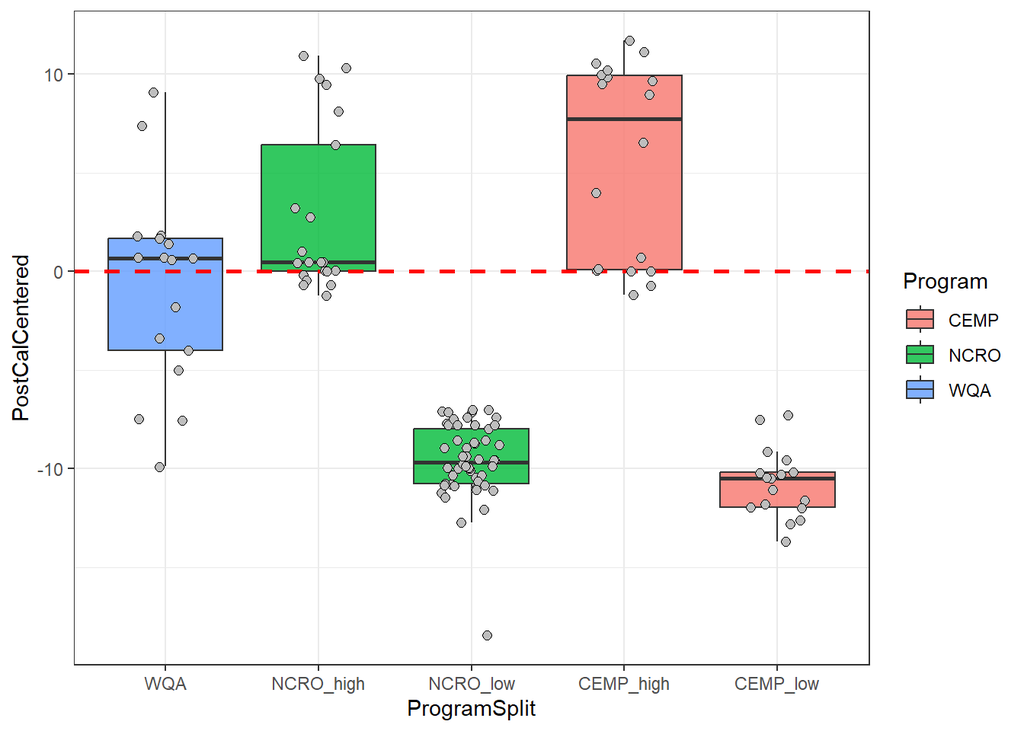

```r
ggplot(df_split, aes(x = ProgramSplit, y = PostCalCentered, fill = Program)) +
  geom_boxplot(alpha = 0.8, outliers = FALSE) +
  geom_hline(yintercept = 0, color = 'red', linetype = 'dashed', linewidth = 1) +
  geom_jitter(width = 0.2, shape = 21, size = 2, fill = 'gray') +
  theme_bw()
```

# Models

## Original (Mod1)

```r
mod1 <- lm(PostCalCentered ~ 1, data = df_turb)

summary(mod1)
```

```
Call:
lm(formula = PostCalCentered ~ 1, data = df_turb)

Residuals:
    Min      1Q  Median      3Q     Max
-14.162  -5.769  -3.197   4.788  16.008

Coefficients:
            Estimate Std. Error t value Pr(>|t|)
(Intercept)  -4.3083     0.6521  -6.607 1.02e-09 ***
---
Signif. codes:  0 '***' 0.001 '**' 0.01 '*' 0.05 '.' 0.1 ' ' 1

Residual standard error: 7.32 on 125 degrees of freedom
```

```
hat values (leverages) are all = 0.007936508
 and there are no factor predictors; no plot no. 5
```

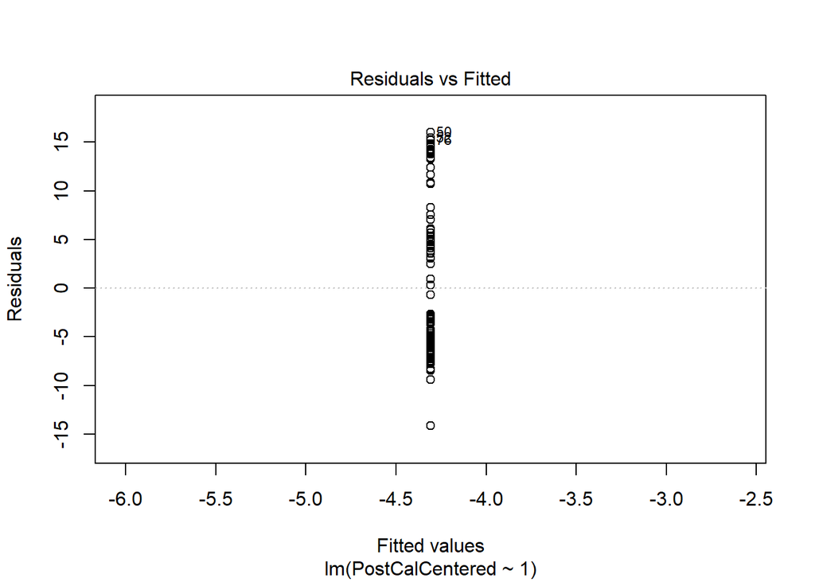

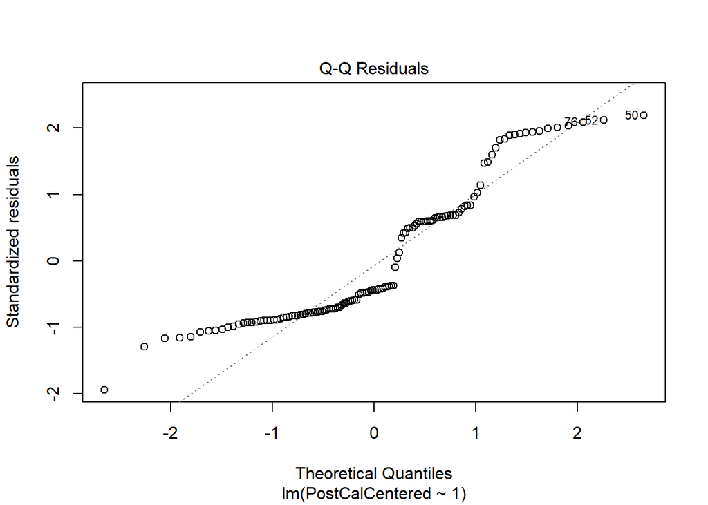

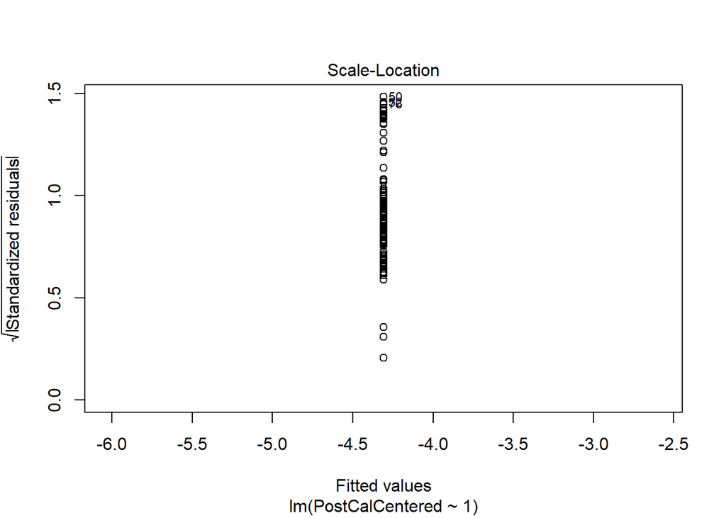

```r
plot(mod1)
```

**Conclusions:**

Clearly a bad model, need to account for some other variable (choosing program).

## Original (Mod2)

```r
mod2r <- lmer(PostCalCentered ~ 1 + (1|Program), data = df_turb, REML = FALSE)

summary(mod2r)
```

```
Linear mixed model fit by maximum likelihood . t-tests use Satterthwaite's
  method [lmerModLmerTest]
Formula: PostCalCentered ~ 1 + (1 | Program)
   Data: df_turb

     AIC      BIC   logLik deviance df.resid
   859.8    868.3   -426.9    853.8      123

Scaled residuals:
    Min      1Q  Median      3Q     Max
-1.8191 -0.7233 -0.3058  0.7015  2.3474

Random effects:
 Groups   Name        Variance Std.Dev.
 Program  (Intercept)  3.624   1.904
 Residual             49.758   7.054
Number of obs: 126, groups:  Program, 3

Fixed effects:
            Estimate Std. Error     df t value Pr(>|t|)
(Intercept)   -3.412      1.309  3.015  -2.606   0.0795 .
---
Signif. codes:  0 '***' 0.001 '**' 0.01 '*' 0.05 '.' 0.1 ' ' 1
```

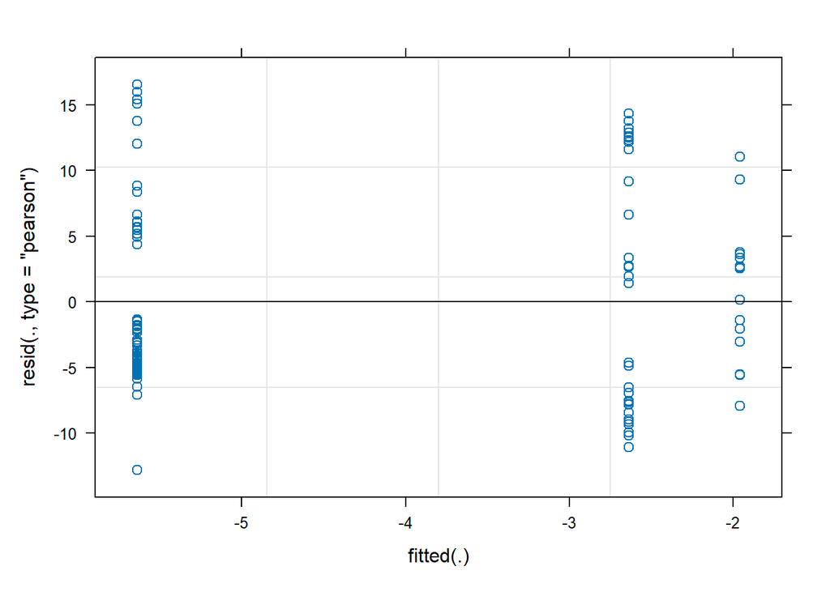

```r
plot(mod2r)
```

```r
ranef(mod2r)
```

```
$Program
     (Intercept)
CEMP   0.7740837
NCRO  -2.2264548
WQA    1.4523711

with conditional variances for "Program"
```

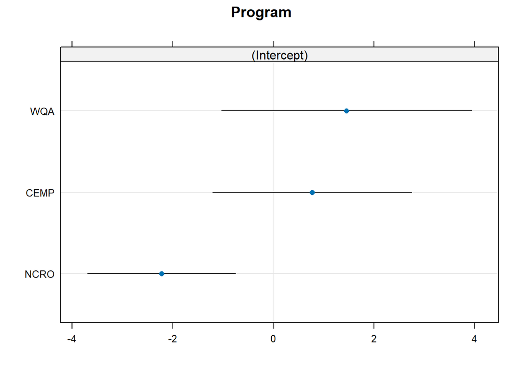

```r
dotplot(ranef(mod2r, condVar = TRUE))
```

```r
mod2f <- lm(PostCalCentered ~ Program, data = df_turb)

summary(mod2f)
```

```
Call:
lm(formula = PostCalCentered ~ Program, data = df_turb)

Residuals:
    Min      1Q  Median      3Q     Max
-12.419  -4.756  -1.854   5.361  16.971

Coefficients:
            Estimate Std. Error t value Pr(>|t|)
(Intercept)   -2.334      1.193  -1.957   0.0526 .
ProgramNCRO   -3.717      1.448  -2.568   0.0114 *
ProgramWQA     1.548      2.086   0.742   0.4596
---
Signif. codes:  0 '***' 0.001 '**' 0.01 '*' 0.05 '.' 0.1 ' ' 1

Residual standard error: 7.057 on 123 degrees of freedom
Multiple R-squared:  0.08542,   Adjusted R-squared:  0.07055
F-statistic: 5.744 on 2 and 123 DF,  p-value: 0.004122
```

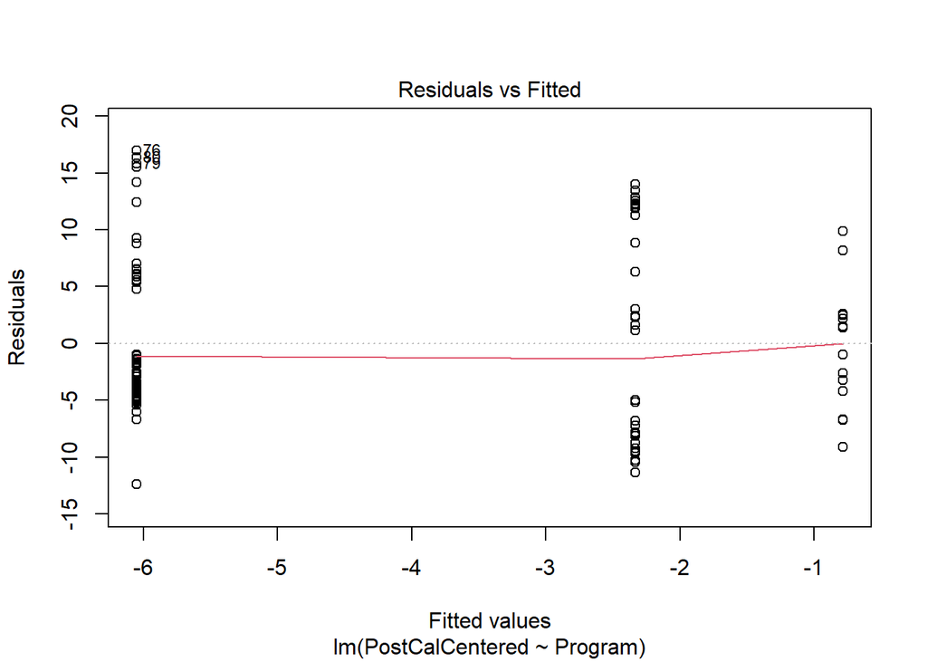

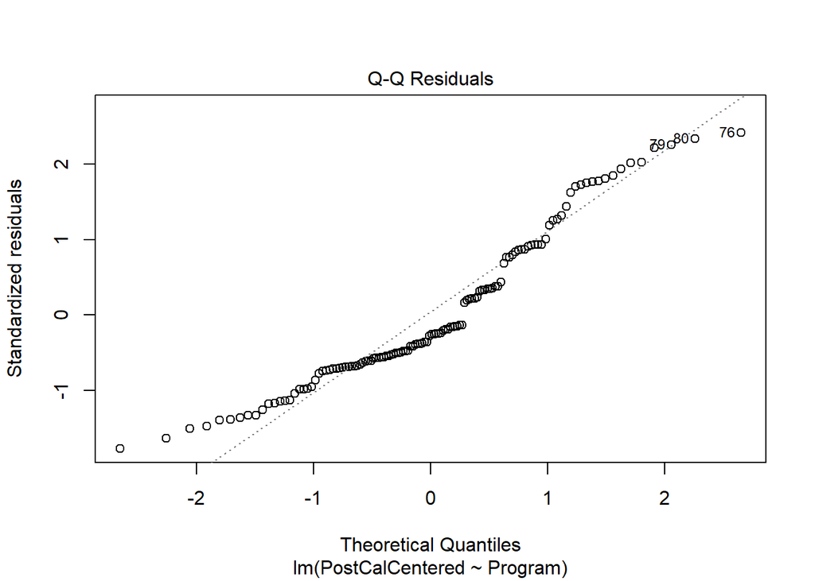

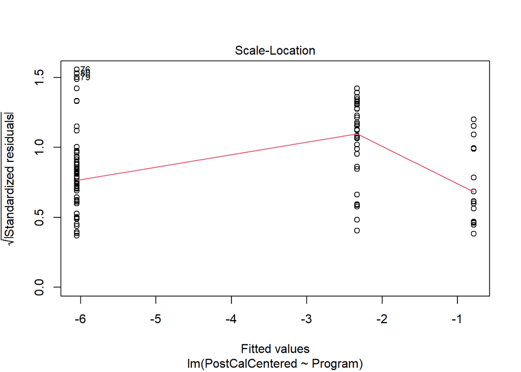

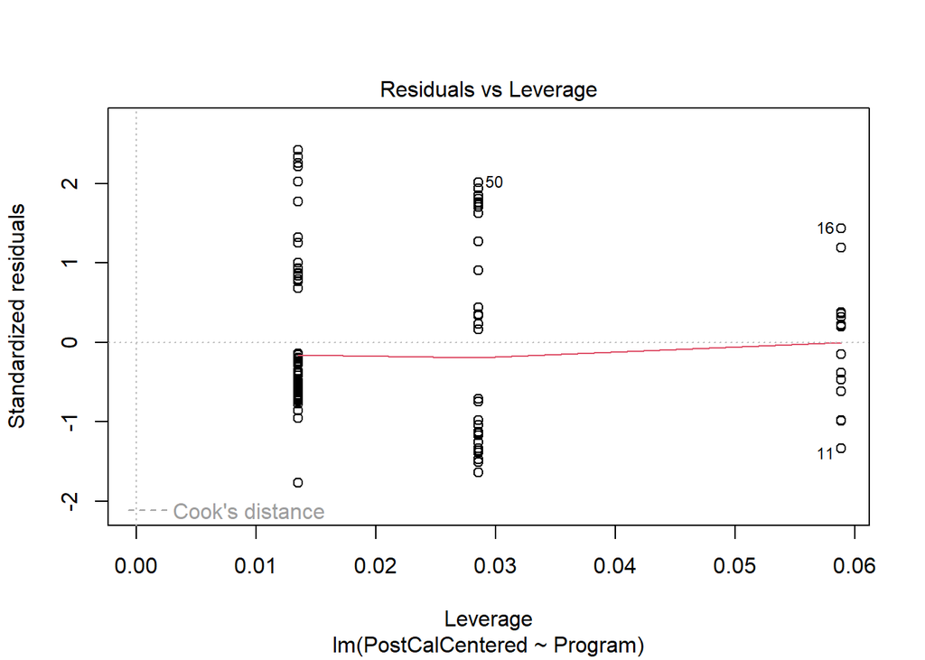

```r
plot(mod2f)
```

```r
emm2f <- emmeans(mod2f, ~ Program)
summary(emm2f, infer = TRUE)
```

```
 Program emmean   SE  df lower.CL upper.CL t.ratio p.value
 CEMP    -2.334 1.19 123    -4.70   0.0271  -1.957  0.0526
 NCRO    -6.051 0.82 123    -7.67  -4.4274  -7.377  <.0001
 WQA     -0.786 1.71 123    -4.17   2.6013  -0.460  0.6467

Confidence level used: 0.95
```

**Conclusions:**

Post-calibration values were not significantly different from the expected value (124) for CEMP and WQA, but were for NCRO. Note this assumes CEMP and NCRO are unimodal populations, which we know isn’t true.

## Split (Mod3)

```r
mod3r <- lmer(PostCalCentered ~ (1|ProgramSplit), data = df_split, REML = FALSE)

summary(mod3r)
```

```
Linear mixed model fit by maximum likelihood . t-tests use Satterthwaite's
  method [lmerModLmerTest]
Formula: PostCalCentered ~ (1 | ProgramSplit)
   Data: df_split

     AIC      BIC   logLik deviance df.resid
   697.8    706.3   -345.9    691.8      123

Scaled residuals:
     Min       1Q   Median       3Q      Max
-2.63184 -0.55027 -0.03196  0.52758  2.86344

Random effects:
 Groups       Name        Variance Std.Dev.
 ProgramSplit (Intercept) 42.67    6.532
 Residual                 11.92    3.452
Number of obs: 126, groups:  ProgramSplit, 5

Fixed effects:
            Estimate Std. Error     df t value Pr(>|t|)
(Intercept)   -2.536      2.941  5.002  -0.862    0.428
```

```r
ranef(mod3r)
```

```
$ProgramSplit
          (Intercept)
WQA          1.721503
NCRO_high    5.353162
NCRO_low    -7.019967
CEMP_high    8.023989
CEMP_low    -8.078687

with conditional variances for "ProgramSplit"
```

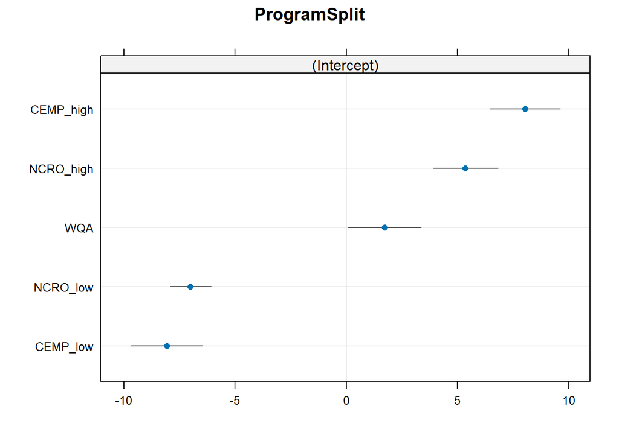

```r
dotplot(ranef(mod3r, condVar = TRUE))
```

```r
mod3f <- lm(PostCalCentered ~ ProgramSplit, data = df_split, REML = FALSE)
summary(mod3f)
```

```
Call:
lm(formula = PostCalCentered ~ ProgramSplit, data = df_split,
    REML = FALSE)

Residuals:
    Min      1Q  Median      3Q     Max
-9.1135 -1.8782 -0.1274  1.8582  9.8565

Coefficients:
                      Estimate Std. Error t value Pr(>|t|)
(Intercept)            -0.7865     0.8373  -0.939  0.34942
ProgramSplitNCRO_high   3.6746     1.1263   3.263  0.00143 **
ProgramSplitNCRO_low   -8.8067     0.9622  -9.153 1.68e-15 ***
ProgramSplitCEMP_high   6.3987     1.1675   5.481 2.35e-07 ***
ProgramSplitCEMP_low   -9.9612     1.1841  -8.413 9.33e-14 ***
---
Signif. codes:  0 '***' 0.001 '**' 0.01 '*' 0.05 '.' 0.1 ' ' 1

Residual standard error: 3.452 on 121 degrees of freedom
Multiple R-squared:  0.7847,    Adjusted R-squared:  0.7776
F-statistic: 110.2 on 4 and 121 DF,  p-value: < 2.2e-16
```

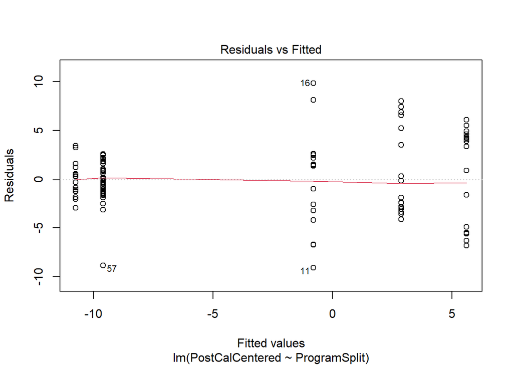

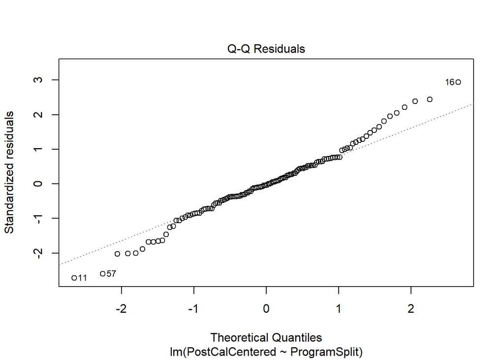

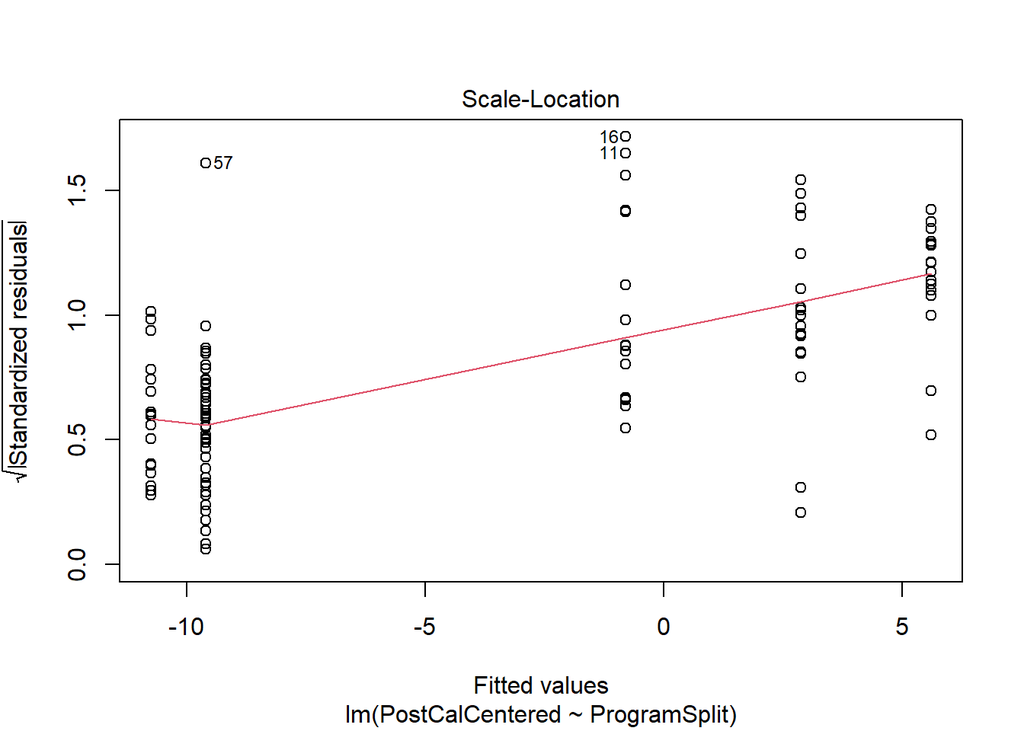

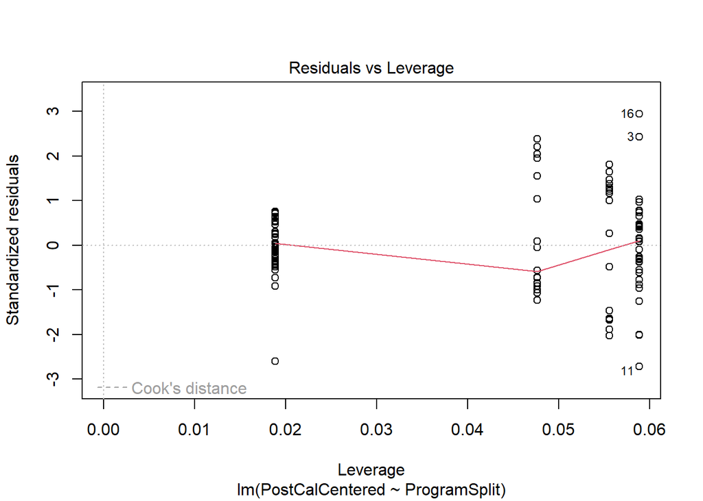

```r
plot(mod3f)
```

```r
emm3f <- emmeans(mod3f, ~ ProgramSplit)
summary(emm3f, infer = TRUE)
```

```
 ProgramSplit  emmean    SE  df lower.CL upper.CL t.ratio p.value
 WQA           -0.786 0.837 121    -2.44    0.871  -0.939  0.3494
 NCRO_high      2.888 0.753 121     1.40    4.379   3.834  0.0002
 NCRO_low      -9.593 0.474 121   -10.53   -8.654 -20.231  <.0001
 CEMP_high      5.612 0.814 121     4.00    7.223   6.897  <.0001
 CEMP_low     -10.748 0.837 121   -12.41   -9.090 -12.837  <.0001

Confidence level used: 0.95
```

**Conclusions:**

When accounting for program-specific effects (random effects model), the grand mean is 124. However, all of the programs have means statistically different from 124 (except maybe WQA).

(Note that, based on these results/the dot plot, this seems to imply that while the NCRO and CEMP data is bimodal and do not include 0, their “unimodal” means are still close to 0. We see that with mod2. Very odd.)

When looking at the fixed-effects model, WQA does not significantly differ from 124, but all the other bimodal programs do.

## Compare models

```r
AIC(mod2f, mod3f)
```

```
      df      AIC
mod2f  4 854.9375
mod3f  6 676.6924
```

```r
BIC(mod2f, mod3f)
```

```
      df      BIC
mod2f  4 866.2826
mod3f  6 693.7101
```

**Conclusions:**

We prefer the insight from our models that account for the bimodal nature of the program data.

# More Plots

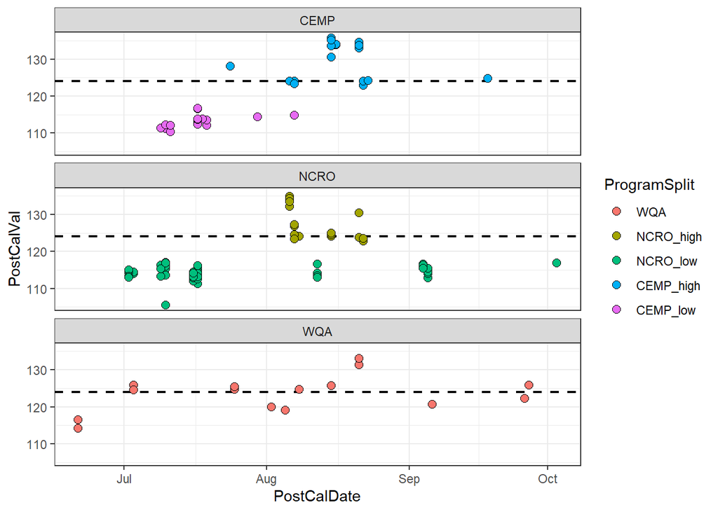

```r
ggplot(df_split, aes(x = PostCalDate, y = PostCalVal, fill = ProgramSplit)) +
  geom_hline(yintercept = 124, color = 'black', linetype = 'dashed', linewidth = 0.8) +
  geom_point(size = 2.5, shape = 21, color = 'black') +
  facet_wrap(~ Program, ncol = 1) +
  theme_bw()
```

# Conclusions

Based on EDA and modeling (particularly mod3), we notice odd bimodal distributions in NCRO and CEMP’s data; when splitting these populations into subgroups, all of them as statistically different from the expected value (124), though they’re balanced enough that removing their effect gives a grand mean that is not statistically different from 124.

It appears that, for CEMP, this is correlated with post-cal timing (low values were recorded earlier than later ones). However, for NCRO, the high values are concentrated in August and low values are evenly distributed throughout the rest of the time span. Further investigation is probably warranted.

Additionally, WQA’s data is not statistically different from 124 and looks otherwise unremarkable.

Recommendation is to further look into the sub-populations for CEMP and NCRO.

(Note using sonde as a predictor was explored but not deemed useful.)

```r
# write_csv(df_split, '05_SpecialStudies/QA_TurbiditySensors/split_data.csv')
```